# Course Introduction and Python Basics

EE1021 Programming for Engineers · Lecture 1 · Fall 2026–2027

Basri Erdogan

## Lecture Goals

1. Understand the **course structure**, grading, weekly flow, and practice expectations
2. Know the tools used in EE1021: **Python 3** and **VS Code** with the Python extension
3. Explain how an **algorithm** becomes statements and expressions in a program
4. Use first Python concepts: **values, types, variables, expressions, and operators**
5. Work with **strings**, indexing, slicing, `print()`, and `input()`

# Part 1: Course Setup

## Instructors

**Instructor**

- Basri ERDOGAN
- Office: 2D-07
- E-mail: `b.erdogan@iku.edu.tr`
- Office hours: Monday 13:00–14:00 and Wednesday 11:00–12:00, or by e-mail appointment

**Lab Assistant**

- Res. Asst. Ahmet Aytuğ AYRANCI
- E-mail: `ahmet.ayranci@iku.edu.tr`
- Available during and after the Thursday lab sessions
- Lab sections and rules: Syllabus tool in CATS

## Welcome to Computer Programming

We will learn to program in Python to solve real-world engineering problems. No prior experience is required, but steady practice matters.

1 **Before class**

Skim the slides and bring one question.

2 **In the lab**

Write, run, and explain your own code.

3 **After class**

Redo one example without looking at the solution.

4 **When stuck**

Ask early in class, lab, office hours, or by e-mail.

## Course Sessions

**Lecture — Wednesday 09:00–10:50, 4C-0406**

- New topic each week, with short predict-and-check exercises
- Ask questions as we go; do not wait until the lab
- Attendance is recorded with the **PUMA** QR code shown in class

**Lab — Thursday, B2 Electrical Lab**

- Section 1 at 11:00–12:50, Section 2 at 13:00–14:50; you attend your own section
- You practise Wednesday’s topic by writing and running code yourself
- Five short **lab quizzes** on paper in weeks 3, 4, 5, 10 and 11 count 20% of the grade; no make-up for a missed quiz
- You may miss at most **two** lab sessions in the term
- **No lab this week (17 September). First lab: Thursday 24 September.**

## Course Roadmap: Weeks 1–6

**Weekly rhythm:** the Wednesday lecture introduces the topic; the Thursday lab practises it. The first lab is in week 2.

01 **Course and Python basics** 16 Sep

Variables, numbers, strings, input and output. No lab this week.

02 **Control flow** 23 Sep

`if` / `else`, `for` and `while`. Lab 1: strings, if-else and loops

03 **Functions and modules** 30 Sep

Built-in functions, your own functions, scope. Lab 2 + Quiz 1

04 **Data structures** 7 Oct

Strings, tuples, lists, dictionaries and sets. Lab 3 + Quiz 2

05 **Debugging, errors and exceptions** 14 Oct

Reading error messages, `try` / `except`. Lab 4 + Quiz 3

06 **Object-oriented programming I** 21 Oct

Classes, objects and methods. Lab 5 and midterm practice; project topics announced

## Course Roadmap: Weeks 7–12

**Second half:** object-oriented programming, then data, files and numerical computing, ending with the project presentations.

07 **No class** 28–29 Oct

Cumhuriyet Bayramı. Make-up days: 7–8 December (MATLAB basics)

08 **Midterm exam** 4 Nov

Written exam in the lecture hour, weeks 1–6. Lab: solutions and review

09 **Object-oriented programming II** 11 Nov

Inheritance and applications. Lab 6; project groups registered

10 **Data and visualisation** 18 Nov

NumPy arrays and matplotlib plots. Lab 7 + Quiz 4

11 **File input/output and CSV** 25 Nov

Reading and writing data files. Lab 8 + Quiz 5

12 **Numerical computing and review** 2 Dec

Lab: project presentations and submission. Final exam: 9–22 December

## Grading

20% **Lab quizzes**

Five short written quizzes in the lab, weeks 3, 4, 5, 10 and 11; the average counts

25% **Midterm**

Written exam in week 8 (4 November): trace and explain code

35% **Final**

Written exam, 9–22 December, covering the whole course

20% **Project**

Group project (3 students): working program, short report and presentation in week 12

Practice homework is not graded. Missed lab quizzes have no make-up. Letter grades: relative evaluation in Orion; at least 20/100 in the final exam is required to pass. Attendance: at least 80%, and no more than two missed lab sessions.

## Tools and Learning Resources

- **Python 3** runs your programs; it is installed on the lab PCs.
- **VS Code** with the Python extension is the course editor. On the lab PCs use the desktop shortcut **EE1021 Python**.
- At home: install Python 3 from python.org, then VS Code and its Python extension. If you already have Anaconda, it also works.
- Course text: Guttag, *Introduction to Computation and Programming Using Python*, 2nd ed. (MIT Press) — free alternative: [Think Python, 3rd edition](https://allendowney.github.io/ThinkPython/)
- Language reference: [The Python Tutorial](https://docs.python.org/3/tutorial/)

1 **Install Python 3**

[python.org/downloads](https://www.python.org/downloads/) — tick “Add python.exe to PATH”

→

2 **Install VS Code + Python extension**

[code.visualstudio.com](https://code.visualstudio.com/), then the Python extension by Microsoft

→

3 **Open a folder and run**

Create `hello.py`, press the Run button, read the output in the terminal.

## Your IDE Workspace

☰🔍▷⊞

EXPLORER

▾ EE1021  
hello.py

hello.py▷ Run

```
name = input("Your name: ")
print("Hello", name)
```

PROBLEMS OUTPUT **TERMINAL**

```
PS C:\Work\1234567> python hello.py
Your name: Ada
Hello Ada
```

⊟ 0 △ 0Ln 2, Col 1Python3.12.10

Course demonstrations and worksheets use VS Code: write code in the editor, press **Run**, read the output in the **TERMINAL** panel, and check the interpreter name in the **Status Bar**.

## First Run: A Power Calculator

Type this program in VS Code, predict the output, and run it.

```python
voltage = 12.0
current = 1.5
power = voltage * current

print("Power:", power, "W")
```

Do not worry about every term yet. The goal is to complete the full cycle: **type → predict → run → inspect → explain**.

## Two Ways to Run Python

**Interactive prompt** — type in the VS Code terminal after `python`

```python
>>> 2 + 3
5
>>> voltage = 12.0
>>> voltage * 1.5
18.0
```

The prompt **answers every expression** you type. Good for trying one line.

**Script** — save `power.py`, press Run

```python
voltage = 12.0
power = voltage * 1.5
power            # shows nothing
print(power)     # shows 18.0
```

A script **shows only what you `print()`**. Good for programs you keep.

Slides marked with `>>>` are prompt examples; everything else is written as a script. Text after `#` is a comment: Python ignores it.

# Part 2: Algorithms and Programs

## What Does a Computer Do?

Fundamentally, a computer:

× **Performs calculations**

Billions of operations per second

▣ **Remembers results**

Values in memory while the program runs; files on disk afterwards

What kinds of calculations?

- Built into the language
- Defined by you as the programmer

We write recipes to make the computer perform tasks.

## A Numerical Example

The square root of a number `x` is `y` such that `y*y = x`.

Recipe for approximating the square root of `x = 16`:

1. Start with a guess, `g`.
2. If `abs(g*g - x) < 0.001`, stop and use `g` as the approximation.
3. Otherwise make a new guess by averaging `g` and `x/g`.
4. Repeat with the new guess until close enough.

You will write this recipe as a `while` loop in week 2; today we only read it.

| Guess `g` | `g × g` | `x / g` | New guess `(g + x/g) / 2` |
| --- | --- | --- | --- |
| 3 | 9 | 5.333 | 4.167 |
| 4.167 | 17.361 | 3.840 | 4.003 |
| 4.003 | 16.024 | 3.997 | 4.000 |

## What Is a Recipe?

1 **Sequence**

Simple steps in a useful order

→

2 **Flow of control**

Rules for deciding when a step runs

→

3 **Stopping condition**

A clear condition for finishing

Sequence + flow of control + stopping condition = **algorithm**.

## From Algorithm to Stored Program

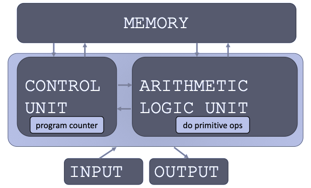

- A stored-program computer keeps instructions and data in memory.
- Instructions perform arithmetic, logic, tests, and data movement.
- The interpreter executes Python statements and evaluates expressions.
- Tests and loops change the flow of control.

## Python Programs

- A Python program contains **statements** and **expressions**. **Statements act, expressions produce.**
- The interpreter executes statements such as assignment and `print()`.
- It evaluates expressions such as `2 + 3` to produce values. Test: if you can write `x =` in front of it, it is an expression.
- Try single lines at the interactive prompt (`>>>`); save longer programs in a `.py` file and run the file.
- Text after `#` is a comment for the reader; the interpreter skips it.

## Values, Objects, Names, and Types

- Every value in Python is an object with a type.
- A type determines which operations are valid.
- Common Lecture 1 examples:
  - Numbers and Boolean values: `int`, `float`, `bool`
  - Text sequences: `str`
- A variable is a **name bound to a value**: a label attached to the value, not a box that holds it (see the binding diagram in two slides).
- Lists and NumPy arrays come later in the course.

## Expressions

- Combine objects and operators to form expressions.
- An expression has a value and a type.
- Pattern for a simple binary expression:

```
<object> <operator> <object>
```

## Binding Variables and Values

The equal sign assigns a value to a variable name.

```python
pi = 3.14159
pi_approx = 22 / 7
```

- The value is stored in computer memory.
- An assignment binds a name to a value.
- Retrieve the value by evaluating the name at the prompt, or by printing it in a script:

```python
>>> pi
3.14159
```

**Try it — predict before running:** at the prompt, what does `>>> pi_approx` display? What does `print(pi_approx)` show in a script?

**Check:** both show approximately `3.142857`; a bare `pi_approx` in a script shows nothing.  
**Watch for:** `=` binds a value to a name; `==` compares two values.

## Changing Bindings

```python
pi = 3.14
radius = 2.2
area = pi * radius ** 2    # 15.1976
radius = 3.2
```

- A new assignment re-binds the name; the old value `2.2` is no longer reachable through `radius`.

**Try it — predict:** after the last line, what is `area`?

**Check:** still `15.1976`. `area` was computed once; it does not follow `radius`. Re-run the formula to update it.

`pi`→3.14

`radius`→3.2

`area`→15.1976

`2.2` is no longer bound to a name; `area` keeps its earlier result.

# Part 3: Values, Variables, and Operators

## Arithmetic Operators on `int` and `float`

| Expression | Meaning |
| --- | --- |
| `x + y` | addition |
| `x - y` | subtraction |
| `x * y` | multiplication |
| `x / y` | division |
| `x % y` | remainder, e.g. `5 % 2 -> 1` |
| `x ** y` | `x` to the power of `y` |
| `x // y` | floor division, e.g. `5 // 2 -> 2` |

**Try it — predict before running:** at the prompt, `>>> 17 // 5` and `>>> 17 % 5`.

**Check:** `3` and `2`.  
**Watch for:** `/` performs ordinary division and returns a `float`.

## Valid Names, Useful Functions, and Precedence

**Variable names**

- May contain letters, digits, and `_`
- Cannot start with a digit
- Cannot contain spaces or `-`
- Are case-sensitive: `speed` and `Speed` differ

```
total_score   valid
3d_point      invalid: starts with a digit
```

**Evaluation helpers**

```python
type(7 / 2)       # float
len("EE1021")     # 6
(4 + 2) * 3       # 18
4 + 2 * 3         # 10
```

Parentheses make the intended order explicit. Without parentheses, powers come before multiplication/division, which come before addition/subtraction.

## Comparison and Logical Operators

| Operator | Meaning |
| --- | --- |
| `x < y` | less than |
| `x > y` | greater than |
| `x <= y` | less than or equal |
| `x >= y` | greater than or equal |
| `x == y` | equal |
| `x != y` | not equal |

Every comparison produces a `bool`: `True` or `False`.

**Try it — predict:** `3 >= 3.0` and `"5" == 5`

**Check:** `True` and `False` — a string is never equal to a number.

For Lecture 1, assume `x` and `y` are Boolean values.

| Operator | Description |
| --- | --- |
| `x and y` | `True` only if both are `True`. |
| `x or y` | `True` if at least one is `True`. |
| `not x` | Reverses `True` and `False`. |

## Assignment and Updating a Value

| Operator | Meaning | Example |
| --- | --- | --- |
| `=` | assignment | `x = 5` |
| `+=` | add and assign | `x += 3` means `x = x + 3` |
| `-=` | subtract and assign | `x -= 2` means `x = x - 2` |
| `*=` | multiply and assign | `x *= 2` means `x = x * 2` |

```python
samples = 8
samples += 2       # samples is now 10
```

The same update pattern also works with `/=`, `//=`, `%=`, and `**=`.

## Operator Checkpoint

**Compute and update**

```python
distance = 17
step = 5

full_steps = distance // step
remainder = distance % step
full_steps += 1
```

Before the update, `full_steps` is `3` and `remainder` is `2`. After the update, `full_steps` is `4`.

**Combine conditions**

```python
has_power = True
is_connected = False

ready = has_power and is_connected
needs_help = not ready
```

`ready` is `False`; `needs_help` is `True`.

# Part 4: Strings and Console I/O

## Strings

- Letters, special characters, spaces, and digits
- Enclosed in double quotation marks or single quotes
- Strings can be concatenated, repeated, and searched:

```python
hi = "hello there"
name = "ana"

greet = hi + name
greeting = hi + " " + name
repeated = (name + " ") * 3
has_a = "a" in name
```

**Try it — predict before running:** `print(greet)` and `print(has_a)`

**Check:** `hello thereana` (no space is added for you) and `True`.

## Strings: Indexing

Square brackets perform indexing into a string.

```python
s = "abc"
```

Indexing starts at `0`; the last element is at index `-1`.

**Try it — predict before running:** if `s = "robot"`, what is `s[-2]`?

**Check:** `"o"`.  
**Watch for:** the first index is `0`, not `1`.

| Expression | Result |
| --- | --- |
| `s[0]` | `"a"` |
| `s[1]` | `"b"` |
| `s[2]` | `"c"` |
| `s[3]` | `IndexError: string index out of range` |
| `s[-1]` | `"c"` |
| `s[-2]` | `"b"` |
| `s[-3]` | `"a"` |

## Strings: Slicing

Use `[start:stop:step]` to slice strings.

- If you give two numbers, `[start:stop]`, then `step = 1` by default.
- You can omit numbers and leave just colons.

```python
s = "abcdefgh"

s[3:6]     # "def", same as s[3:6:1]
s[3:6:2]   # "df"
s[::]      # "abcdefgh", same as s[0:len(s):1]
s[::-1]    # "hgfedcba", same as s[-1:-(len(s)+1):-1]
s[4:1:-2]  # "ec"
```

## Console Input and Output

**Display a result with `print()`**

```python
voltage = 5
print("Voltage:", voltage, "V")
```

Convert numeric input before calculating:

```python
num = int(input("Type a number... "))
print(5 * num)
```

**Read text with `input()`**

`input()` displays a prompt and waits for the user to press Enter.

```python
text = input("Type anything... ")
print(5 * text)
```

`input()` always returns a string. Use `int()` or `float()` when you need a number.

**Try it — predict before running:** if the user types `7`, what does `print(5 * text)` display?

**Check:** `77777`.  
**Watch for:** `input()` returns a string; use `int()` or `float()` when you need a number.

## Five-Minute Exit Ticket

Answer without running Python first. Then check your answers in VS Code.

1. What value and type does `7 // 2` produce? And `7 / 2`?
2. If `unit = "volt"`, what do `unit[-1]`, `unit[1:3]`, and `unit * 2` produce?
3. After `x = 5`, `x += 2`, `x *= 3`, what is `x`? Which line would fail if `x` had been read with `input()` and not converted?

**Check:** `3` (`int`) and `3.5` (`float`); `"t"`, `"ol"`, `"voltvolt"`; `21` — `x += 2` fails because `input()` returns a string.

## Summary

- An algorithm is a precise recipe with a sequence, flow of control, and stopping condition.
- A Python program contains statements and expressions.
- Variables bind names to values; every value has a type.
- Expressions combine values and operators to produce new values.
- Python uses operators for arithmetic, comparisons, logic, assignment, and membership.
- Strings support indexing and slicing.
- `print()` displays output; `input()` receives text from the user.